# TD 3 - Structures de contrôle et fonctions

Nel Hervé

2024-09-05

# Structures de contrôle

## Boucle if

```r
n = 81
n
```

```
## [1] 81
```

```r
# premier exemple : n est-il pair ?
if (n%%2 == 0){
  print('Pair')
} else {
  print('Impair')
}
```

```
## [1] "Impair"
```

```r
# deuxième exemple : n est-il un carré parfait ?
if (sqrt(n) == as.integer(sqrt(n))){
  print('Carré parfait')
} else {
  print('Pas un carré parfait')
}
```

```
## [1] "Carré parfait"
```

## Boucle for

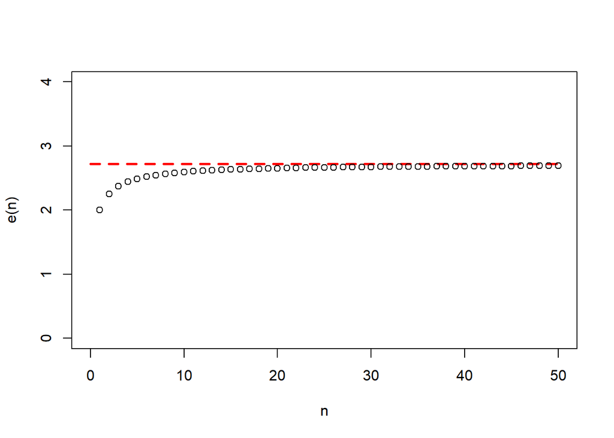

```r
# exemple : illustrer la convergence de la suite des (1 + 1/n)^n vers e

# création d'un graphique vide :
plot(NULL, xlim = c(0, 50), ylim = c(0, 4), xlab = 'n', ylab = 'e(n)')

# tracé, en pointillés, d'une droite horizontale à y = e :
x = seq(0, 50, length.out = 1000)
lines(x = x, y = rep(exp(1), 1000), col = 'red', lwd = 2.5, lty = 2)

# ajout des points correpondant à la suite :
for (n in c(1:50)){
  e = (1 + 1/n)**n
  points(x = n, y = e)
}
```

### Exercice 1

On place 1000€ sur un compte épargne. Le taux d’intérêt est de 0.5% par an. Quelle somme a-t-on gagné au bout de 10 ans ?

## Boucle while

```r
# créons un programme capable de déterminer la puissance de 2 dans la décomposition en produit de facteurs premiers d'un nombre n :
n = 48
k = 0

while (n%%2 == 0){
  k = k+1
  n = n/2
}

k
```

```
## [1] 4
```

### Exercice 2

On se propose l’expérience suivante : un participant choisit un nombre “mystère” entre 1 et 100. Un autre participant essaie ensuite de deviner ce nombre ; il fait une proposition, et s’il ne devine pas le nombre mystère, il tente un autre nombre, jusqu’à tomber sur le bon résultat.

On compte le nombre de tentatives qu’il faut au second participant pour deviner le nombre mystère.

1. Créer un programme illustrant cette expérience, qui affiche le nombre de tentatives.

*Indice : pour tirer un nombre aléatoire entre 1 et k, on utilise la fonction sample (voir help(sample) ou ?sample)*

Bonus : En utilisant le programme précédent, répéter l’expérience 1000 fois, et donner le nombre moyen de tentatives avant d’arriver au bon résultat.

## Boucle repeat

```r
# on reprend le programme exemple de la boucle while :

n = 48
k = 0

repeat{
  if (n%%2 == 1) break
  k = k+1
  n = n/2
}

k
```

```
## [1] 4
```

### Exercice 3

On choisit un nombre entier, et on se donne l’algorithme suivant :

- si le nombre est pair, le diviser par 2 ;
- sinon, le multiplier par 3 et ajouter 1.

On répète l’algorithme sur le nombre obtenu jusqu’à ce qu’on arrive à 1 (ce qui, selon la conjecture de Syracuse, finira forcément par arriver).

Créer un programme affichant, pour un nombre donné :

- le vecteur des valeurs calculées par l’algorithme ;
- le nombre d’itérations nécessaires pour arriver à 1.

# Création de fonctions

```r
# en reprenant à nouveau l'exemple précédent, on crée une fonction capable de donner, pour n'importe quel nombre, la puissance de 2 dans sa décomposition en produit de facteurs premiers :

puiss_2 = function(n){
  k=0

  while (n%%2 == 0){
  k = k+1
  n = n/2
  }
  return(k)
}

puiss_2(48)
```

```
## [1] 4
```

```r
puiss_2(6)
```

```
## [1] 1
```

### Exercice 4

1. Reprendre l’exercice 1 et créer une fonction généralisant le calcul à n’importe quels montant initial, taux et nombre d’années.
2. Reprendre l’exercice 2 et créer une fonction permettant de calculer, pour un nombre de répétitions donné, le nombre moyen de tentatives nécessaires pour deviner le nombre mystère.

### Exercice 5

On reprend l’algorithme de l’exercice 3.

1. Créer une fonction qui donne, pour un nombre donné, le nombre d’itérations nécessaires pour arriver à 1.
2. Représenter les résultats précédents dans un graphique, pour des nombres allant de 2 à 100.
3. Quel nombre requiert le plus d’itérations avant d’arriver à 1 ? Repasser le point en rouge sur le graphique.

## Avertissements et erreurs

```r
# on se propose de recoder la fonction factorial, qui calcule n! pour un nombre n donné.
# ici, si l'argument de la fonction est un nombre entier, elle s'exécute ; si c'est un décimal, elle affiche un avertissement, et prend l'arrondi ; si c'est un nombre négatif, elle s'arrête avec un message d'erreur.

fact = function(n){
  if (n != as.integer(n)){
    warning("Nombre décimal, arrondi à l'entier le plus proche \n")
    n = floor(n)
  }
  if (n == 0){
    return(1)
  }
  if (n < 0){
    stop('Factorielle non définie pour des nombres négatifs')
  }
  k = 1
  for (i in c(1:n)){
    k = k*i
  }
  return(k)
}

fact(0)
```

```
## [1] 1
```

```r
fact(5)
```

```
## [1] 120
```

```r
fact(4.3)
```

```
## [1] 24
```

```r
fact(-1)
```

```
## Error in fact(-1): Factorielle non définie pour des nombres négatifs
```